# “Titanic EDA”

“Claire Eichenberg”

2023-11-25

## Exploratory Data Analysis of the Titanic Dataset

##This is a cleaned version of the titanic (training) dataset [published on Kaggle]

##(https://www.kaggle.com/jamesleslie/titanic-cleaned-data?select=train_clean.csv). Here is a quick statistical summary.

## **** NOTE: THE KAGGLE DATASET “train_clean” ABOVE IS THE SAME AS MY “TITANIC” DATASET FROM “titanic_partial.xlsx” *******

##THIS titanic_partial.xlsx dataset already had the Titles cleaned so they don’t look like Mr. or Mrs. but instead Mr or Mrs. I was told to use “stringr” as part of the assignment and it could have been used to clean the Mr. to Mr as described above. The code to do that would have used the original titanic dataset and done this:

#use str_detect with filter also ifelse !! *** ifelse is if/else logic ***

#titanic <- titanic %>%

#mutate(title_new = ifelse(str_detect(titanic$Name, “Mr\.”), “Mr”,

#ifelse(str_detect(titanic$Name, “Mrs\.”), “Mrs”,“Other”)))

#This makes an equivalent column to the column 13 Title column with no periods in the titles, except for my analysis I wanted to keep the Miss and Master, Dr and Rev titles because I wanted to see if young/unmarried people died more than married people or not, so I didn’t use “Other”.

```
##       Age           Cabin             Embarked              Fare
##  Min.   : 0.42   Length:891         Length:891         Min.   :  0.00
##  1st Qu.:22.00   Class :character   Class :character   1st Qu.:  7.91
##  Median :30.00   Mode  :character   Mode  :character   Median : 14.45
##  Mean   :29.45                                         Mean   : 32.20
##  3rd Qu.:35.50                                         3rd Qu.: 31.00
##  Max.   :80.00                                         Max.   :512.33
##      Name               Parch         PassengerId        Pclass
##  Length:891         Min.   :0.0000   Min.   :  1.0   Min.   :1.000
##  Class :character   1st Qu.:0.0000   1st Qu.:223.5   1st Qu.:2.000
##  Mode  :character   Median :0.0000   Median :446.0   Median :3.000
##                     Mean   :0.3816   Mean   :446.0   Mean   :2.309
##                     3rd Qu.:0.0000   3rd Qu.:668.5   3rd Qu.:3.000
##                     Max.   :6.0000   Max.   :891.0   Max.   :3.000
##      Sex                SibSp          Survived         Ticket
##  Length:891         Min.   :0.000   Min.   :0.0000   Length:891
##  Class :character   1st Qu.:0.000   1st Qu.:0.0000   Class :character
##  Mode  :character   Median :0.000   Median :0.0000   Mode  :character
##                     Mean   :0.523   Mean   :0.3838
##                     3rd Qu.:1.000   3rd Qu.:1.0000
##                     Max.   :8.000   Max.   :1.0000
##     Title            Family_Size
##  Length:891         Min.   : 0.0000
##  Class :character   1st Qu.: 0.0000
##  Mode  :character   Median : 0.0000
##                     Mean   : 0.9046
##                     3rd Qu.: 1.0000
##                     Max.   :10.0000
```

SINGLE VARIABLE ANALYSIS

#To Do: inspect all of the variable distributions.

#The variables are Age, Cabin (converted to Cabin_deck in column 15), Embarked, Fare, Name, Parch (parents or children of passenger), Passenger ID (3 digit number), Pclass (1,2,3), Sex (male/female), SibSp (Siblings or Spouses), Survived (0=no, 1= yes), Ticket (various letters/numbers, all different, not useful), Title (Master (young boy), Miss, Mr, Mrs, Dr, Rev), Family Size (the sum of SibSp + Parch, a created column), Cabin_deck (A,B,C,D,E,F,G,U (unknown) where all C123, C586, etc are grouped into deck C, etc). The single variable assessment of each variable is below in the order given above.

###### COLUMN 1 “AGE”, USING BOXPLOT BECAUSE BARCHART ISN’T FEASIBLE FOR SO MANY DIFFERENT AGES, NEED STATISTICS

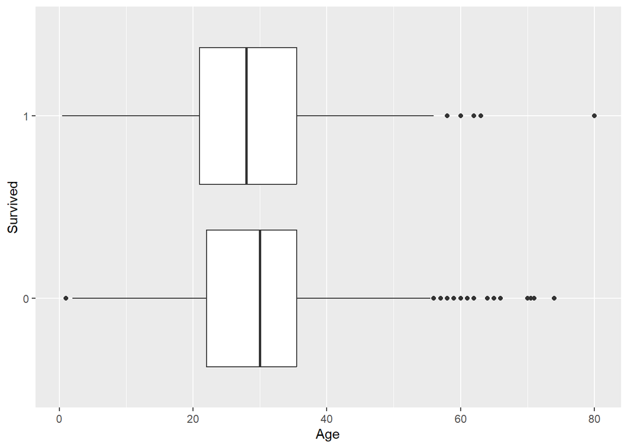

```r
##SINGLE VARIABLE ANALYSIS OF ** AGE ** LOOKS LIKE YOUNGER PEOPLE SURVIVED A BIT BETTER, BUT NOT STRONG TREND
titanic$Survived <- as.factor(titanic$Survived)
ggplot(data=titanic, mapping = aes(x = Survived, y = Age)) +
  geom_boxplot() +
      coord_flip()
```